# Classification

The data is taken from site https://data.fivethirtyeight.com/.

```python
#import CSV file
import pandas as pd
```

```python
from google.colab import files
```

```python
file = files.upload()
```

Upload widget is only available when the cell has been executed in the current browser session. Please rerun this cell to enable.

```
Saving mlb_elo_latest.csv to mlb_elo_latest.csv
```

```python
#Read CSV file
import io
data = pd.read_csv(io.BytesIO(file['mlb_elo_latest.csv']))
```

Let's display few rows of data and dimension of the data

```python
print(data.head)
```

```
<bound method NDFrame.head of             date  season  neutral  ... rating2_post score1 score2
0     2019-10-30    2019        0  ...  1583.382133      2      6
1     2019-10-29    2019        0  ...  1580.329587      2      7
2     2019-10-27    2019        0  ...  1595.165625      1      7
3     2019-10-26    2019        0  ...  1592.633477      1      8
4     2019-10-25    2019        0  ...  1587.640180      1      4
...          ...     ...      ...  ...          ...    ...    ...
2461  2019-03-28    2019        0  ...  1524.424808      5      4
2462  2019-03-28    2019        0  ...  1524.171277      0      2
2463  2019-03-28    2019        0  ...  1420.675155      7      2
2464  2019-03-21    2019        1  ...  1493.483066      4      5
2465  2019-03-20    2019        1  ...  1492.270839      7      9

[2466 rows x 26 columns]>
```

Let's now find out the missing value in the data

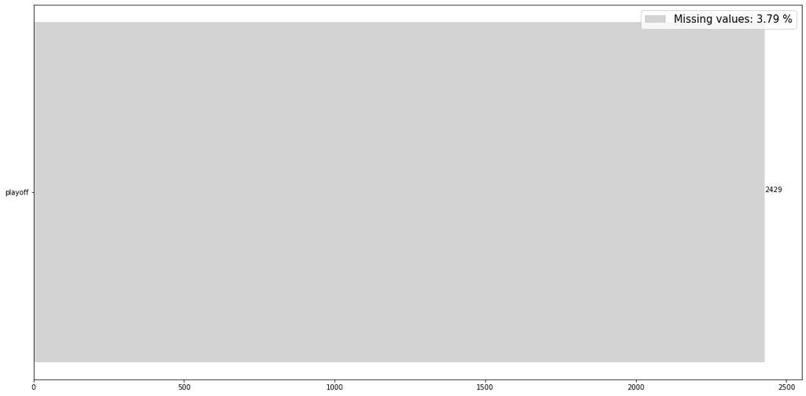

```python
#Finding missing values
#!pip install draw_missing
import drawmissing as d
o = d.Draw(data)
o.draw_missing_plot()
```

We can see from above graph that 3.79% of total data is missing and out of 2466 rows 2429 rows are missing from the column playoffs. So, it is better to drop thi column as it is of no use.

```python
data = data.drop(columns='playoff')
```

Missing values are removed now lets know all the data types of the remaining columns. Also, lets print the description of data.

```python
print(data.head)
print(data.shape)
```

```
<bound method NDFrame.head of             date  season  neutral  ... rating2_post score1  score2
0     2019-10-30    2019        0  ...  1583.382133      2       6
1     2019-10-29    2019        0  ...  1580.329587      2       7
2     2019-10-27    2019        0  ...  1595.165625      1       7
3     2019-10-26    2019        0  ...  1592.633477      1       8
4     2019-10-25    2019        0  ...  1587.640180      1       4
...          ...     ...      ...  ...          ...    ...     ...
2461  2019-03-28    2019        0  ...  1524.424808      5       4
2462  2019-03-28    2019        0  ...  1524.171277      0       2
2463  2019-03-28    2019        0  ...  1420.675155      7       2
2464  2019-03-21    2019        1  ...  1493.483066      4       5
2465  2019-03-20    2019        1  ...  1492.270839      7       9

[2466 rows x 25 columns]>
(2466, 25)
```

Lets make a new column Team1_result so that we can classify whether the team1 wins or lose

```python
#Creating team1_result column
import numpy as np
team1_result = np.where(data["score1"] > data["score2"], '1', '0')
team1_result = team1_result.tolist()
data['team1_result'] = team1_result
```

```python
print(data.describe())
print(data.dtypes)
```

```
       season      neutral     elo1_pre  ...  rating2_post       score1       score2
count  2466.0  2466.000000  2466.000000  ...   2466.000000  2466.000000  2466.000000
mean   2019.0     0.004055  1506.168379  ...   1506.114484     4.807786     4.829278
std       0.0     0.063564    43.519823  ...     45.671326     3.214627     3.419733
min    2019.0     0.000000  1380.751101  ...   1383.386088     0.000000     0.000000
25%    2019.0     0.000000  1473.271275  ...   1475.074492     2.000000     2.000000
50%    2019.0     0.000000  1508.948173  ...   1512.334986     4.000000     4.000000
75%    2019.0     0.000000  1540.122431  ...   1537.760914     7.000000     7.000000
max    2019.0     1.000000  1605.069000  ...   1599.127939    21.000000    23.000000

[8 rows x 20 columns]
date             object
season            int64
neutral           int64
team1            object
team2            object
elo1_pre        float64
elo2_pre        float64
elo_prob1       float64
elo_prob2       float64
elo1_post       float64
elo2_post       float64
rating1_pre     float64
rating2_pre     float64
pitcher1         object
pitcher2         object
pitcher1_rgs    float64
pitcher2_rgs    float64
pitcher1_adj    float64
pitcher2_adj    float64
rating_prob1    float64
rating_prob2    float64
rating1_post    float64
rating2_post    float64
score1            int64
score2            int64
team1_result     object
dtype: object
```

```python
data['team1_result'] = data['team1_result'].astype(int)
```

There are too many columns in out dataset which can affect our classification model. Therefore let's remove some of the least related columns to make data appropriate for classification.

```python
from matplotlib import pyplot
```

```
              season   neutral  elo1_pre  ...    score1    score2  team1_result
season           NaN       NaN       NaN  ...       NaN       NaN           NaN
neutral          NaN  1.000000  0.000249  ...  0.015728  0.074106     -0.041976
elo1_pre         NaN  0.000249  1.000000  ...  0.130259 -0.145773      0.173793
elo2_pre         NaN  0.036496 -0.020434  ... -0.088338  0.108883     -0.142685
elo_prob1        NaN -0.050579  0.717764  ...  0.152528 -0.180031      0.222471
elo_prob2        NaN  0.050579 -0.717764  ... -0.152528  0.180031     -0.222471
elo1_post        NaN -0.001706  0.998338  ...  0.165568 -0.184064      0.225479
elo2_post        NaN  0.038374 -0.022758  ... -0.124005  0.147553     -0.194799
rating1_pre      NaN -0.001865  0.971979  ...  0.131727 -0.162216      0.187518
rating2_pre      NaN  0.035814 -0.028847  ... -0.089709  0.109498     -0.142660
pitcher1_rgs     NaN -0.034265  0.422927  ...  0.051637 -0.123811      0.100529
pitcher2_rgs     NaN  0.024515 -0.005971  ... -0.120163  0.015499     -0.087420
pitcher1_adj     NaN -0.025854 -0.029494  ... -0.020689 -0.068810      0.018074
pitcher2_adj     NaN  0.018950  0.024162  ... -0.064960 -0.031798     -0.021474
rating_prob1     NaN -0.058666  0.649949  ...  0.156981 -0.190263      0.229061
rating_prob2     NaN  0.058666 -0.649949  ... -0.156981  0.190263     -0.229061
rating1_post     NaN -0.003114  0.970867  ...  0.156645 -0.189236      0.224131
rating2_post     NaN  0.037043 -0.030491  ... -0.115002  0.136971     -0.179799
score1           NaN  0.015728  0.130259  ...  1.000000  0.022551      0.533928
score2           NaN  0.074106 -0.145773  ...  0.022551  1.000000     -0.572967
team1_result     NaN -0.041976  0.173793  ...  0.533928 -0.572967      1.000000

[21 rows x 21 columns]
```

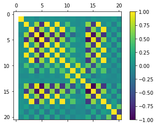

```python
cor = data.corr()
print(cor)
plt = pyplot.figure()
x = plt.add_subplot(111)
y = x.matshow(cor, vmin=-1, vmax=1)
plt.colorbar(y)
pyplot.show()
```

As there is no corelation betweeen of season with any column we remove that column. Also, there negative corelation of columns 'neutral', 'elo2_pre','elo_prob2','elo2_post','rating2_pre','pitcher2_rgs',''score2','pitcher2_adj','rating_prob2', 'rating2_post'. So we remove those columns.

```python
data = data.drop(columns=['season','neutral', 'elo2_pre','elo_prob2','elo2_post','rating2_pre','pitcher2_rgs','score2','pitcher2_adj','rating_prob2', 'rating2_post'])
```

```python
print(data.describe())
print(data.dtypes)
```

```
          elo1_pre    elo_prob1  ...       score1  team1_result
count  2466.000000  2466.000000  ...  2466.000000   2466.000000
mean   1506.168379     0.533702  ...     4.807786      0.528386
std      43.519823     0.086752  ...     3.214627      0.499295
min    1380.751101     0.271628  ...     0.000000      0.000000
25%    1473.271275     0.476678  ...     2.000000      0.000000
50%    1508.948173     0.535252  ...     4.000000      1.000000
75%    1540.122431     0.593987  ...     7.000000      1.000000
max    1605.069000     0.775112  ...    21.000000      1.000000

[8 rows x 10 columns]
date             object
team1            object
team2            object
elo1_pre        float64
elo_prob1       float64
elo1_post       float64
rating1_pre     float64
pitcher1         object
pitcher2         object
pitcher1_rgs    float64
pitcher1_adj    float64
rating_prob1    float64
rating1_post    float64
score1            int64
team1_result      int64
dtype: object
```

We also remove categorical variables, 'team1', 'team2','date', 'pitcher1','pitcher2' as the categorical variables can affect our predictions.

```python
data = data.drop(['date','team1','team2','pitcher1','pitcher2'],axis=1)
```

```python
print(data.describe())
print(data.dtypes)
```

```
          elo1_pre    elo_prob1  ...       score1  team1_result
count  2466.000000  2466.000000  ...  2466.000000   2466.000000
mean   1506.168379     0.533702  ...     4.807786      0.528386
std      43.519823     0.086752  ...     3.214627      0.499295
min    1380.751101     0.271628  ...     0.000000      0.000000
25%    1473.271275     0.476678  ...     2.000000      0.000000
50%    1508.948173     0.535252  ...     4.000000      1.000000
75%    1540.122431     0.593987  ...     7.000000      1.000000
max    1605.069000     0.775112  ...    21.000000      1.000000

[8 rows x 10 columns]
elo1_pre        float64
elo_prob1       float64
elo1_post       float64
rating1_pre     float64
pitcher1_rgs    float64
pitcher1_adj    float64
rating_prob1    float64
rating1_post    float64
score1            int64
team1_result      int64
dtype: object
```

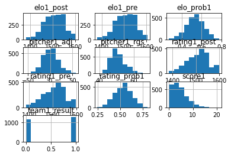

```python
hist_data=data.hist()
```

```
              elo1_pre  elo_prob1  ...    score1  team1_result
elo1_pre      1.000000   0.717764  ...  0.130259      0.173793
elo_prob1     0.717764   1.000000  ...  0.152528      0.222471
elo1_post     0.998338   0.716859  ...  0.165568      0.225479
rating1_pre   0.971979   0.710047  ...  0.131727      0.187518
pitcher1_rgs  0.422927   0.303873  ...  0.051637      0.100529
pitcher1_adj -0.029494  -0.033645  ... -0.020689      0.018074
rating_prob1  0.649949   0.915201  ...  0.156981      0.229061
rating1_post  0.970867   0.709271  ...  0.156645      0.224131
score1        0.130259   0.152528  ...  1.000000      0.533928
team1_result  0.173793   0.222471  ...  0.533928      1.000000

[10 rows x 10 columns]
```

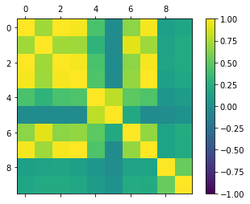

```python
cor = data.corr()
print(cor)
plt = pyplot.figure()
x = plt.add_subplot(111)
y = x.matshow(cor, vmin=-1, vmax=1)
plt.colorbar(y)
pyplot.show()
```

There are no dark blue or violet celss which indicates that data is ready to be applied to the model.

```python
data_balance = data.groupby('team1_result').size()
print (data_balance)
```

```
team1_result
0    1163
1    1303
dtype: int64
```

Number of 1s and 0s are pretty much balanced and there is no need to balance them any further

```python
from sklearn.neighbors import KNeighborsClassifier
from sklearn.metrics import accuracy_score
from sklearn.metrics import f1_score
```

Now we will split the data into training and testing data and will start building the model.

```python
inputvar = data.iloc[0:,0:9]
outputvar = data.iloc[:,-1]
```

Input variables for classification

```python
inputvar
```

|  | elo1_pre | elo_prob1 | elo1_post | rating1_pre | pitcher1_rgs | pitcher1_adj | rating_prob1 | rating1_post | score1 |
| --- | --- | --- | --- | --- | --- | --- | --- | --- | --- |
| 0 | 1599.542804 | 0.574617 | 1594.882297 | 1591.026009 | 56.920649 | 0.989236 | 0.515172 | 1587.973463 | 2 |
| 1 | 1605.069000 | 0.595209 | 1599.542804 | 1595.165625 | 62.975093 | 28.723451 | 0.594638 | 1591.026009 | 2 |
| 2 | 1584.005206 | 0.515546 | 1578.837182 | 1578.722119 | 49.433198 | -29.811205 | 0.373102 | 1576.189971 | 1 |
| 3 | 1589.985555 | 0.538425 | 1584.005206 | 1583.715416 | 56.003581 | 0.823752 | 0.586974 | 1578.722119 | 1 |
| 4 | 1593.827376 | 0.553044 | 1589.985555 | 1586.428733 | 54.036365 | -9.053908 | 0.526852 | 1583.715416 | 1 |
| ... | ... | ... | ... | ... | ... | ... | ... | ... | ... |
| 2461 | 1539.739468 | 0.560411 | 1540.955109 | 1529.140344 | 54.035982 | 16.056535 | 0.536027 | 1530.115045 | 5 |
| 2462 | 1515.935946 | 0.558821 | 1513.801421 | 1536.346491 | 62.669388 | 36.897491 | 0.529543 | 1534.830993 | 0 |
| 2463 | 1543.454311 | 0.663576 | 1545.161285 | 1569.184157 | 55.851946 | 12.596364 | 0.757372 | 1569.956639 | 7 |
| 2464 | 1538.451430 | 0.539971 | 1536.797652 | 1519.121831 | 45.343580 | -9.598335 | 0.529336 | 1517.909603 | 4 |
| 2465 | 1540.662576 | 0.546288 | 1538.451430 | 1520.811136 | 50.867044 | 15.661717 | 0.549029 | 1519.121831 | 7 |

2466 rows × 9 columns

Output variable for classification team1_result

```python
outputvar
```

```
0       0
1       0
2       0
3       0
4       0
       ..
2461    1
2462    0
2463    1
2464    0
2465    0
Name: team1_result, Length: 2466, dtype: int64
```

Now lets split the data in training and testing dataset.

```python
from sklearn.model_selection import train_test_split
```

```python
inputvar_train, inputvar_test, outputvar_train, outputvar_test = train_test_split(inputvar,outputvar,test_size = 0.3, random_state = 30)
```

```python
print(inputvar_train)
```

```
         elo1_pre  elo_prob1    elo1_post  ...  rating_prob1  rating1_post  score1
2170  1530.653665   0.565771  1526.802063  ...      0.526909   1521.243139       0
461   1515.554270   0.429007  1519.388816  ...      0.392172   1515.276363      11
1030  1573.863229   0.570463  1575.971589  ...      0.586580   1583.811427       6
2039  1545.020836   0.562651  1547.149208  ...      0.542961   1540.950952       5
1568  1475.513380   0.500005  1473.196798  ...      0.528589   1483.832643       6
...           ...        ...          ...  ...           ...           ...     ...
919   1454.512596   0.412660  1452.508278  ...      0.400548   1451.859718       2
1164  1501.722883   0.510044  1500.255447  ...      0.504444   1499.203533       6
500   1478.292496   0.394327  1477.247157  ...      0.402015   1469.757251       4
421   1481.717708   0.549053  1477.420170  ...      0.545707   1467.268973       3
1829  1497.241740   0.540483  1498.514770  ...      0.491361   1519.727735       7

[1726 rows x 9 columns]
```

```python
print(outputvar_train)
```

```
2170    0
461     1
1030    1
2039    1
1568    0
       ..
919     0
1164    0
500     0
421     0
1829    1
Name: team1_result, Length: 1726, dtype: int64
```

```python
print(inputvar_test)
```

```
         elo1_pre  elo_prob1    elo1_post  ...  rating_prob1  rating1_post  score1
1314  1484.211424   0.553415  1485.450587  ...      0.516282   1488.710916      11
940   1491.554413   0.570351  1488.055621  ...      0.578431   1505.391596       2
438   1554.034871   0.698014  1555.845426  ...      0.701105   1557.688288       7
1161  1418.734366   0.345571  1417.430072  ...      0.301301   1416.309651       6
1244  1516.701934   0.508675  1513.667643  ...      0.492332   1508.929788       2
...           ...        ...          ...  ...           ...           ...     ...
1521  1456.948729   0.442479  1454.160572  ...      0.423834   1459.321657       0
904   1492.258813   0.526648  1493.960806  ...      0.560351   1504.541970       3
1954  1533.794986   0.581198  1535.285145  ...      0.521899   1529.716852       5
349   1567.432010   0.762679  1564.859622  ...      0.719483   1550.157362       4
2385  1508.600186   0.558349  1509.809315  ...      0.456628   1531.738593       9

[740 rows x 9 columns]
```

```python
print(outputvar_test)
```

```
1314    1
940     0
438     1
1161    0
1244    0
       ..
1521    0
904     1
1954    1
349     0
2385    1
Name: team1_result, Length: 740, dtype: int64
```

Now lets fit the model using train dataset.

```python
mod = KNeighborsClassifier(n_neighbors=3)
mod.fit(inputvar_train,outputvar_train)
```

```
KNeighborsClassifier(algorithm='auto', leaf_size=30, metric='minkowski',
                     metric_params=None, n_jobs=None, n_neighbors=3, p=2,
                     weights='uniform')
```

Predicting the values using test dataset.

```python
predtest1 = mod.predict(inputvar_test)
print(predtest1)
```

```
[1 0 1 0 0 1 0 1 0 0 0 1 1 0 0 1 1 1 0 0 1 1 1 1 0 0 0 1 1 0 0 0 0 0 1 1 0
 0 0 1 1 0 1 1 0 1 1 1 1 0 0 1 1 1 1 1 1 0 1 0 1 1 0 0 1 0 0 1 1 0 0 1 0 1
 0 1 0 1 1 0 0 0 0 0 1 1 1 0 0 1 1 1 0 0 0 0 1 1 0 1 1 1 1 0 0 0 1 1 1 1 0
 1 0 1 0 0 0 1 0 1 0 0 0 1 1 0 1 1 0 1 0 1 1 1 1 0 1 1 0 1 0 1 0 1 0 0 1 0
 1 1 1 0 1 0 1 0 1 1 1 1 1 1 0 1 0 1 0 1 1 0 0 0 1 1 0 1 0 1 1 1 1 0 0 0 1
 1 0 1 1 1 0 0 1 0 1 1 1 0 0 0 0 0 0 0 1 1 1 0 1 0 1 0 0 1 0 1 1 1 1 1 0 1
 0 1 0 1 1 0 1 1 1 1 1 0 0 1 1 1 1 0 1 0 1 0 0 0 1 0 0 0 0 1 0 1 1 0 1 1 1
 1 0 0 1 1 0 0 1 0 1 1 1 0 0 0 0 1 1 0 0 0 0 0 0 1 1 0 0 1 0 1 0 1 1 1 0 0
 1 1 0 0 1 0 1 0 0 1 1 0 0 1 1 1 0 0 0 1 1 0 1 1 1 0 0 1 1 0 0 0 1 0 1 0 0
 0 1 1 0 1 1 1 1 0 0 0 0 0 1 1 0 1 0 0 0 0 1 1 1 1 1 1 1 1 0 0 0 1 1 0 1 0
 1 0 0 1 1 1 0 1 0 1 1 1 0 1 0 0 0 1 0 0 1 0 1 1 1 0 0 0 0 1 0 1 0 1 1 0 1
 1 1 1 0 1 1 1 1 1 1 1 1 0 0 0 0 0 1 0 0 0 1 0 0 0 0 1 1 1 0 0 0 1 0 0 1 0
 0 1 1 1 0 0 1 1 1 1 1 1 0 1 0 0 1 1 0 1 1 1 0 1 0 1 1 1 0 1 0 0 0 1 1 1 1
 0 0 0 0 1 0 0 1 1 1 1 1 0 1 0 1 1 0 1 0 0 1 1 1 0 1 1 1 0 1 0 1 0 1 1 1 1
 0 0 1 0 0 1 0 1 1 1 0 1 0 0 0 0 1 1 1 1 0 1 0 0 1 0 0 0 1 1 0 0 1 1 0 1 0
 1 0 0 1 1 0 1 0 1 0 1 0 1 0 1 1 1 0 1 1 0 1 1 1 1 1 0 1 1 0 0 0 1 0 0 0 1
 1 0 0 1 0 1 0 0 1 1 0 0 0 0 1 1 1 1 1 1 0 0 1 1 0 1 0 1 1 1 1 0 1 1 0 1 1
 0 0 1 0 0 1 1 0 0 1 1 1 1 1 0 0 1 0 0 0 1 0 0 0 1 1 1 1 0 1 1 0 1 1 1 0 0
 1 0 0 0 0 1 1 1 0 1 0 0 1 1 0 0 0 0 1 0 1 1 1 0 0 1 0 0 1 1 1 1 0 0 1 0 0
 1 0 1 1 0 0 1 0 1 1 1 1 1 1 0 1 1 0 1 1 1 1 1 0 1 0 0 1 0 1 0 0 0 0 1 0 0]
```

Evaluating our model

```python
#Calculating accuracy
accu= accuracy_score(outputvar_test,predtest1)
print('Accuracy with KNN Model', accu)
f1s = f1_score(outputvar_test,predtest1, average  = 'weighted' )
print('F1-score with KNN Model', f1s)
```

```
Accuracy with KNN Model 0.754054054054054
F1-score with KNN Model 0.7538738738738738
```